# UCell signature enrichment analysis

In this demo, we will apply UCell to evaluate gene signatures in a set of CD45+ single cells from 48 tumor biopsies of melanoma patients, sequenced using the Smart-seq2 protocol [Sade-Feldman et al. (2018) Cell](https://pubmed.ncbi.nlm.nih.gov/30388456/).

## Installation

```r
remotes::install_github("carmonalab/UCell")

library(UCell)
library(Matrix)
set.seed(123)
```

## scRNA-seq data preparation

Download the gene expression matrix for this study from Gene Expression Omnibus - GSE120575

```r
BiocManager::install("GEOquery")
library(GEOquery)

cached.object <- "SadeFeldman.expmat.rds"
if (!file.exists(cached.object)) {
    geo_acc <- "GSE120575"
    gse <- getGEO(geo_acc)

    series <- paste0(geo_acc, "_series_matrix.txt.gz")
    getGEOSuppFiles(geo_acc)

    ## Load expression matrix and metadata
    exp.mat <- read.delim(sprintf("%s/GSE120575_Sade_Feldman_melanoma_single_cells_TPM_GEO.txt.gz",
        geo_acc), header = F, sep = "\t")
    genes <- exp.mat[c(-1, -2), 1]
    cells <- as.vector(t(exp.mat[1, 2:16292]))
    samples <- as.factor(t(exp.mat[2, 2:16292]))

    exp.mat <- exp.mat[c(-1, -2), 2:16292]
    colnames(exp.mat) <- cells
    rownames(exp.mat) <- genes

    # Make sparse
    exp.mat <- Matrix::Matrix(as.matrix(exp.mat), sparse = T)
    saveRDS(exp.mat, "SadeFeldman.expmat.rds")
}
```

Alternatively, get the same matrix already processed in sparse format (much faster to load) at [THIS LINK](https://drive.switch.ch/index.php/s/JCAWvnlxCmOvG42)

And then load it using:

```r
exp.mat <- readRDS("SadeFeldman.expmat.rds")
```

## Define gene signatures

Here we define some simple gene sets for immune cells based on the “Human Cell Landscape” signatures [Han et al. (2020) Nature](https://www.nature.com/articles/s41586-020-2157-4)

```r
set.seed(123)
signatures <- list(Macrophage = c("CTSB", "C1QB", "LAPTM5", "TYROBP", "PSAP", "C1QA",
    "HLA-DRA", "CTSD", "NPC2", "FCER1G"), Tcell = c("CD3D", "CD3E", "CD3G", "CD4",
    "CD2", "CD7", "TRAC", "LAT"), Bcell = c("MS4A1", "CD79A", "CD79B", "CD19", "BANK1",
    "BCL11A", "CD22", "NCF1C"), Neutrophil = c("SRGN", "AZU1", "MPO", "MS4A3", "RNASE2",
    "ELANE", "DEFA4", "CTSG", "PRTN3", "DEFA3"), Myeloid_cell = c("CD14", "CYP17A1",
    "CSF1R", "FCER1G", "SPI1"), NKcell = c("FCGR3A", "KLRF1", "NCR1", "FGFBP2", "FCGR3A"))
```

## Run UCell

Run `ScoreSignatures_UCell` and get directly signature scores for all cells

```r
u.scores <- ScoreSignatures_UCell(exp.mat, features = signatures)
u.scores[1:8, 1:3]
```

```
           Macrophage_UCell Tcell_UCell Bcell_UCell
A10_P3_M11       0.19416667  0.08275000  0.00000000
A11_P1_M11       0.01796667  0.41591667  0.10070833
A11_P3_M11       0.14506667  0.36958333  0.00000000
A11_P4_M11       0.26070000  0.55491667  0.08704167
A12_P3_M11       0.05356667  0.28629167  0.00000000
A12_P6_M11       0.17870000  0.46516667  0.00000000
A2_P1_M11        0.00000000  0.09458333  0.00000000
A2_P4_M11        0.00000000  0.33537500  0.00000000
```

Show the distribution of predicted scores

```r
library(reshape2)
library(ggplot2)
melted <- melt(u.scores)
colnames(melted) <- c("Cell", "Signature", "Uscore")
p <- ggplot(melted, aes(x = Signature, y = Uscore)) + geom_violin(aes(fill = Signature),
    scale = "width") + geom_boxplot(width = 0.1) + theme_bw() + theme(axis.text.x = element_blank())
p
```

[output not shown]

## Pre-calculating gene rankings

The time- and memory-demanding step in UCell is the calculation of gene rankings for each individual cell. If we plan to experiment with signatures, editing them or adding new cell subtypes, it is possible to pre-calculate the gene rankings once and for all and then apply new signatures over these pre-calculated ranks. Run the `StoreRankings_UCell` function to pre-calculate gene rankings over a dataset:

```r
set.seed(123)
ranks <- StoreRankings_UCell(exp.mat)
ranks[1:5, 1:5]
```

```
5 x 5 sparse Matrix of class "dgCMatrix"
         A10_P3_M11 A11_P1_M11 A11_P3_M11 A11_P4_M11 A12_P3_M11
TSPAN6            .          .          .          .          .
TNMD              .          .          .          .          .
DPM1              .        514          .       1130          .
SCYL3             .          .          .          .          .
C1orf112          .          .          .          .          .
```

Then, we can apply our signature set, or any other new signature to the pre-calculated ranks. The calculations will be considerably faster.

```r
set.seed(123)
u.scores.2 <- ScoreSignatures_UCell(features = signatures, precalc.ranks = ranks)

melted <- melt(u.scores.2)
colnames(melted) <- c("Cell", "Signature", "Uscore")
p <- ggplot(melted, aes(x = Signature, y = Uscore)) + geom_violin(aes(fill = Signature),
    scale = "width") + geom_boxplot(width = 0.1) + theme_bw() + theme(axis.text.x = element_blank())
p
```

[output not shown]

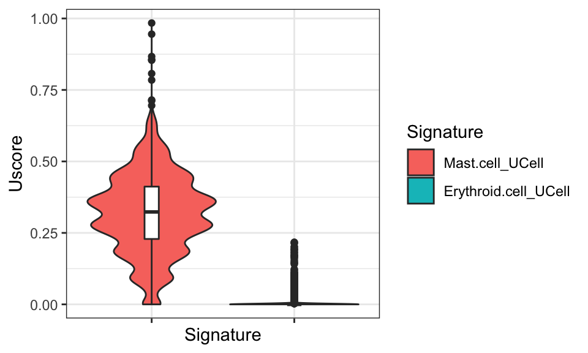

```r
new.signatures <- list(Mast.cell = c("TPSAB1", "TPSB2", "CPA3", "SRGN", "RGS2", "RGS1",
    "NFKBIA", "GLUL", "VIM", "ANXA1"), Erythroid.cell = c("HBA2", "HBG2", "HBA1",
    "HBB", "HBG1", "AHSP", "ALAS2", "SLC25A37", "HBM"))

u.scores.3 <- ScoreSignatures_UCell(features = new.signatures, precalc.ranks = ranks)
melted <- melt(u.scores.3)
colnames(melted) <- c("Cell", "Signature", "Uscore")
p <- ggplot(melted, aes(x = Signature, y = Uscore)) + geom_violin(aes(fill = Signature),
    scale = "width") + geom_boxplot(width = 0.1) + theme_bw() + theme(axis.text.x = element_blank())
p
```

## Visualizing results

We can see how the signatures distribute on low-dimensional representations of the data, for instance by creating a Seurat object from the expression matrix.

```r
library(Seurat)
seurat.object <- CreateSeuratObject(counts = exp.mat, project = "SadeFeldman")

seurat.object <- AddMetaData(seurat.object, metadata = as.data.frame(u.scores))
head(seurat.object@meta.data)
```

```
           orig.ident nCount_RNA nFeature_RNA Macrophage_UCell Tcell_UCell
A10_P3_M11        A10   14624.81         2050       0.19416667   0.0827500
A11_P1_M11        A11   11933.60         1573       0.01796667   0.4159167
A11_P3_M11        A11   11888.79         1591       0.14506667   0.3695833
A11_P4_M11        A11   19693.54         2909       0.26070000   0.5549167
A12_P3_M11        A12    9186.06         1211       0.05356667   0.2862917
A12_P6_M11        A12   18240.40         2715       0.17870000   0.4651667
           Bcell_UCell Neutrophil_UCell Myeloid_cell_UCell NKcell_UCell
A10_P3_M11  0.00000000       0.09486667          0.1250667        0.273
A11_P1_M11  0.10070833       0.09666667          0.0000000        0.000
A11_P3_M11  0.00000000       0.10173333          0.0000000        0.000
A11_P4_M11  0.08704167       0.10200000          0.0000000        0.000
A12_P3_M11  0.00000000       0.00000000          0.0000000        0.000
A12_P6_M11  0.00000000       0.09940000          0.0000000        0.000
```

Generate PCA and UMAP embeddings

```r
seurat.object <- NormalizeData(seurat.object, verbose = FALSE)
seurat.object <- FindVariableFeatures(seurat.object, selection.method = "vst", nfeatures = 1000,
    verbose = FALSE)

seurat.object <- ScaleData(seurat.object)
seurat.object <- RunPCA(seurat.object, features = seurat.object@assays$RNA@var.features,
    verbose = FALSE)
seurat.object <- RunUMAP(seurat.object, reduction = "pca", dims = 1:20, seed.use = 123,
    verbose = FALSE)
```

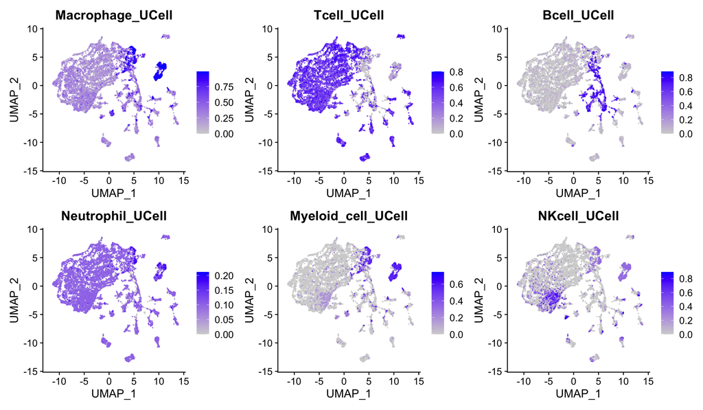

```r
signature.names <- paste0(names(signatures), "_UCell")
FeaturePlot(seurat.object, reduction = "umap", features = signature.names, ncol = 3,
    order = T)
```

UCell also implements a wrapper to interact directly with Seurat (see function `AddModuleScore_UCell`). See [THIS VIGNETTE](https://carmonalab.github.io/UCell/UCell_Seurat_vignette.html) for an application of UCell to PBMCs stored in a Seurat object.

## Multi-core processing

If your machine has multi-core capabilities and enough RAM, running UCell in parallel can speed up considerably your analysis. In this example we will use 4 parallel cores:

```r
u.scores <- ScoreSignatures_UCell(exp.mat, features = signatures, ncores = 4)

melted <- melt(u.scores)
colnames(melted) <- c("Cell", "Signature", "Uscore")
p <- ggplot(melted, aes(x = Signature, y = Uscore)) + geom_violin(aes(fill = Signature),
    scale = "width") + geom_boxplot(width = 0.1) + theme_bw() + theme(axis.text.x = element_blank())
p
```

[output not shown]

## Further reading

To see how UCell can interact directly with Seurat see [THIS VIGNETTE](https://carmonalab.github.io/UCell/UCell_Seurat_vignette.html)

The code and the package are available at the UCell [GitHub repository](https://github.com/carmonalab/UCell)